# Cow Creek

Sadie Gill, Mark Tompkins

July 2020

## Future Data Improvements

None planned.

## Instream Spawning and Rearing Habitat

**Data Source:** [FWS 2011](https://s3-us-west-2.amazonaws.com/cvpiahabitat-r-package/cvpia-sit-model-inputs/FWS2011_SouthCowrpt.pdf) (pg 19) and [Calculated with a relationship between flow and mean weighted usable area from watersheds in the region with modeled habitat](http://cvpia-habitat-docs-markdown.s3-website-us-west-2.amazonaws.com/watershed/Regional_Approximation.html)

There were no watershed specific instream spawning habitat data available for Cow Creek. Instream spawning data for Cow Creek were developed using a regional approximation of similar watersheds in the Upper-mid Sacramento River Region. The data were then used in the Decision Support Model (DSM).

The instream rearing habitat for Fall Run Chinook Salmon in South Cow Creek is based on data from the Fish and Wildlife Service South Cow Creek habitat assessment. The study gathered rearing data from the Valley Floor Segment and the Boero Segment of South Cow Creek. The rearing data from both stretches are provided in figures 9 and 10 on page 19. The rearing habitat data were provided to us by Mark Gard from the California Department of Fish and Wildlife in a [spreadsheet](https://cvpiahabitat-r-package.s3-us-west-2.amazonaws.com/IFIMWUA.xlsx). Mark Gard instructed us to the ‘SouthCow’ tab within the spreadsheet. The cells A2:C32 represent the Valley Floor Reach (5.11 miles) and cells A36:C66 represent the Boero Reach (1.68 miles). Units are in square feet per 1000 feet.

### Rearing Data

Header Descriptions: flow_cfs = flow in cubic feet per second, FR_fry_wua = Fall Run Chinook Fry WUA, FR_juv_wua = Fall Run Chinook Juvenile WUA, watershed = section of stream modeled for CVPIA SDM

| flow_cfs | FR_fry_wua | FR_juv_wua | watershed |
| --- | --- | --- | --- |
| 10 | 12208.28 | 3748.369 | Cow Creek |
| 20 | 11880.26 | 4673.649 | Cow Creek |
| 30 | 12324.15 | 5031.646 | Cow Creek |
| 40 | 12859.06 | 5662.284 | Cow Creek |
| 50 | 13409.94 | 6190.437 | Cow Creek |

*… with 25 more rows*

### Rearing WUA

The following plot shows the weighted usable rearing area (WUA) in square feet per thousand feet for Fall Run Chinook Salmon fry and juvenile. These rates are multiplied by the total rearing reach length mapped by the Science Integration Team (SIT) to estimate available habitat.

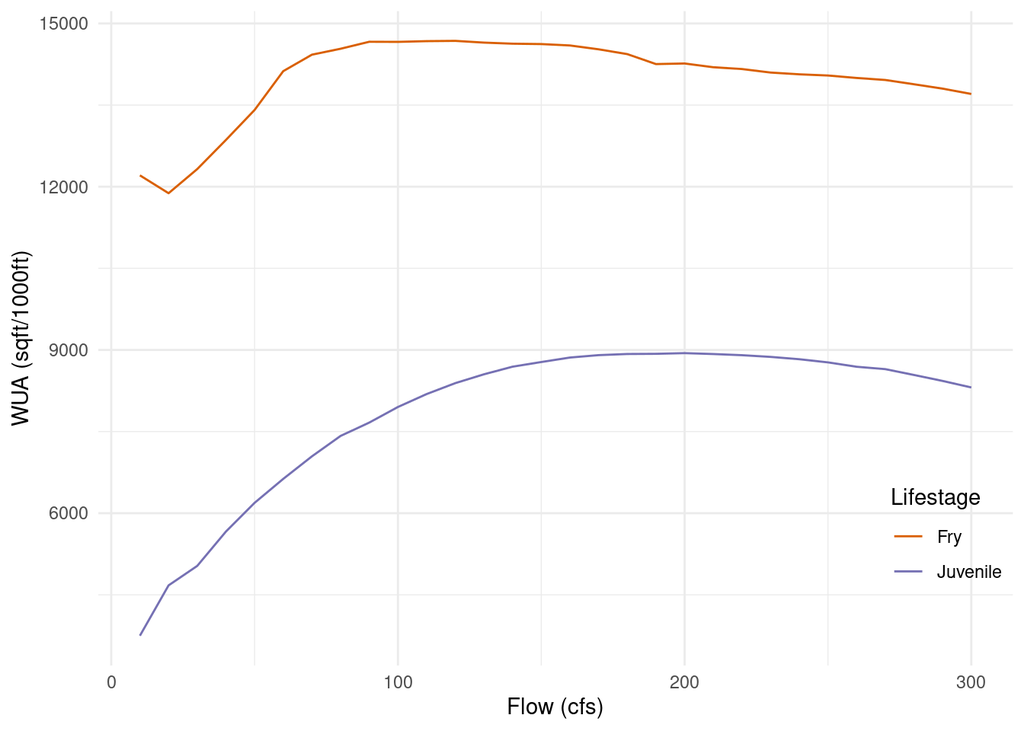

## Floodplain Rearing Habitat

**Data Source:** Scaled from a Deer Creek flow to floodplain area relationship generated with a [2D HEC-RAS hydraulic model](https://cvpiahabitat-r-package.s3.us-west-2.amazonaws.com/cvpia-sit-model-inputs/DeerCreek_2Dmodel_FlowWest_Final.pdf). See [Deer Creek HSI modeling documentation](http://cvpia-habitat-docs-markdown.s3-website-us-west-2.amazonaws.com/watershed/deer_creek.html) for more details.

### Fall Run

There was no watershed specific hydraulic modeling available for Cow Creek. A flow to inundated floodplain area relationship was generated for Cow Creek by scaling the flow to inundated floodplain area relationship for Deer Creek. This scaling used the ratio of mean flow from December to June between the modeled and unmodeled watershed. Flows and corresponding inundated floodplain areas per unit length were calculated for Cow Creek as 216% of Deer Creek. Of the entire mapped 79 miles rearing extent in Cow Creek, 8.6 miles were classified as low gradient and 70.4 miles were classified as high gradient based on a geomorphic analysis of long profile slopes and valley widths. The area per unit length was scaled by a factor of 0.1 for the high gradient extent. There was no scaling factor applied to the low gradient extent.

### Steelhead

There was no watershed specific hydraulic modeling available for Cow Creek. A flow to inundated floodplain area relationship was generated for Cow Creek by scaling the flow to inundated floodplain area relationship for Deer Creek. This scaling used the ratio of mean flow from December to June between the modeled and unmodeled watershed. Flows and corresponding inundated floodplain areas per unit length were calculated for Cow Creek as 216% of Deer Creek. Of the entire mapped 104.3 miles rearing extent in Cow Creek, 8.6 miles were classified as low gradient and 95.7 miles were classified as high gradient based on a geomorphic analysis of long profile slopes and valley widths. The area per unit length was scaled by a factor of 0.1 for the high gradient extent. There was no scaling factor applied to the low gradient extent.

## Floodplain Data

The areas represent total inundated area in acres.

Header Descriptions: flow_cfs = flow in cubic feet per second, FR_floodplain_acres = Fall Run Chinook floodplain acres, ST_floodplain_acres = Steelhead floodplain acres, watershed = section of stream modeled for CVPIA SDM

| flow_cfs | FR_floodplain_acres | ST_floodplain_acres | watershed |
| --- | --- | --- | --- |
| 1941 | 0.00 | 0.00 | Cow Creek |
| 2156 | 16.46 | 24.74 | Cow Creek |
| 6469 | 235.39 | 353.72 | Cow Creek |
| 10781 | 404.04 | 607.14 | Cow Creek |
| 12937 | 463.61 | 696.66 | Cow Creek |

*… with 8 more rows*

## Floodplain Plot

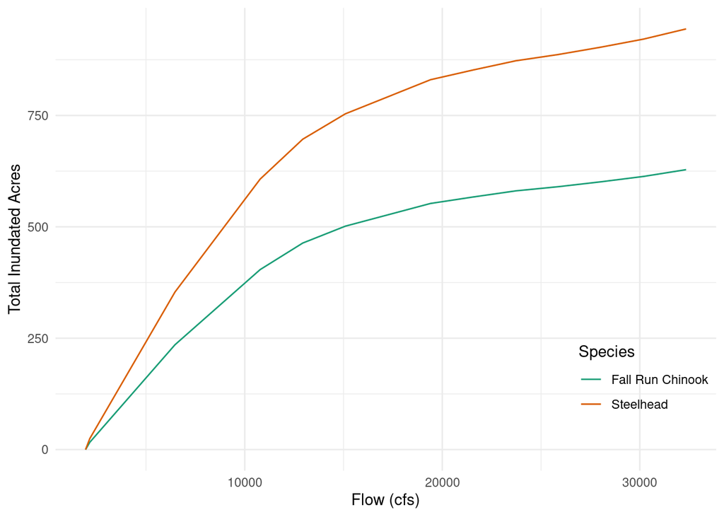